# regression_tree

## Regression tree

Meng Lu, Jiong Wang

## Content:

- Regression tree
- Cost complexity pruning
- Tree visualisation
- Feature selection

```python
import numpy as np
import matplotlib.pyplot as plt
# Import sklearn along with all necessary modules
from sklearn.linear_model import LinearRegression
from sklearn.tree import DecisionTreeRegressor
from sklearn.model_selection import train_test_split
from sklearn.metrics import r2_score, mean_squared_error, explained_variance_score, mean_absolute_error, mean_absolute_percentage_error
from sklearn import tree # visualising tree

import functools
import itertools
```

```python
# We can define a function for exporting the accuracy metrics later.
def performance (actural, pred):
    r2 = r2_score(actural, pred)
    expvar = explained_variance_score(actural, pred)
    mae = mean_absolute_error(actural, pred)
    #RMSE
    rmse = np.sqrt(mean_squared_error(actural, pred))
    # for between data-set comparison
    mape = mean_absolute_percentage_error(actural, pred)
    m ={"R2":r2, "expvar":expvar,"MAE": mae, "RMSE": rmse, "MAPE": mape}
    return (m)
```

```
(500, 1) (500, 1)
```

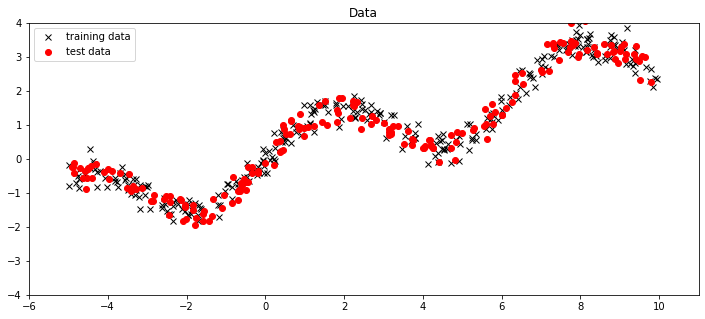

```python
# Let's get started!
# Define the true function for generating the dummy dataset
def func(x):
    # Generate sample dataset from a linearly transformed sinusoidal function: y=sin(x)+0.3*x+e (where 'e' is random noise)
    return np.sin(x) + .3*x

def funclin(x):
    return .8*x-2

# Define function for generating dummy dataset
def dummyData(func, sample_size, std):
    # Artificially generate input x
    x = np.random.rand(sample_size)[:,None]; x=x*15-5
    # Call function to generate response y
    y = func(x) + np.random.normal(scale=std, size=x.shape)
    return x, y

# A simple function to split your dataset into 'training' and 'validation' sets.
# Note that we need to split them randomly.

# Prepare training and validation
x, y = dummyData(func, 500, 0.25)  # Generate data points by using function defined in section 0.0
# try linear function
#x, y = dummyData(funclin, 500, 0.25)  # Generate data points by using function defined in section 0.0

print(x.shape, y.shape)
x_train,  x_val,y_train, y_val = train_test_split(x, y, test_size=0.4, random_state=7)

x_all = np.linspace(-5, 10, 100).reshape(-1,1)

y_true = func(x_all)
#y_true = funclin(x_all)

# Visualize the artificially generated dataset
plt.figure(figsize=(12,5))
plt.xlim([-6., 11])
plt.ylim([-4, 4])
plt.title('Data')
plt.plot(x_train,y_train,'kx',label='training data')
plt.plot(x_val,y_val,'ro',label='test data')
plt.legend()
```

### Regression Tree

```python
# Source: https://austindavidbrown.github.io/post/2019/01/regression-decision-trees-in-python/

# First, let's compile the Decision Tree model
# This time you define a class instead of a function for decision tree for regression
class RegTree():
    # You need a function to evaluate model performance as we did before
    @staticmethod
    def mse(v):
        return np.mean(np.square(v - np.mean(v)))

    # You also need a function to split/classify the dataset at each of the tree node
    @staticmethod
    def splitData(X, y, feature_index, feature_value):
        return {
            "I_left": np.where(X[:, feature_index] <= feature_value)[0],
            "I_right": np.where(X[:, feature_index] > feature_value)[0],
        }

    # You also need criteria to split/classify
    # Here, a algorithm calld Greedy algorithm is used for finding the best split
    @staticmethod
    def greedyBestSplit(X, y):
        best_feature_index = 0
        best_split_value = 0
        best_dloss = 0
        best_split = {
            "I_left": np.array([]),
            "I_right": np.array([]),
        }

        n_features = X.shape[1]
        parent_mse = RegTree.mse(y)
        N = y.shape[0]
        for feature_index in range(0, n_features):
            split_values = np.unique(X[:, feature_index])
            for split_value in split_values:
                split = RegTree.splitData(X, y, feature_index, split_value)

                # If there is a split
                if split["I_left"].shape[0] > 0 and split["I_right"].shape[0] > 0:
                    # Compute the change in loss
                    N_left = split["I_left"].shape[0]
                    N_right = split["I_right"].shape[0]
                    dloss = parent_mse - 1/N * (N_left * RegTree.mse(y[split["I_left"]]) + N_right * RegTree.mse(y[split["I_right"]]))

                    # Update if the change in loss is the largest so far
                    if dloss >= best_dloss:
                        best_feature_index = feature_index
                        best_split_value = split_value
                        best_split = split
                        best_dloss = dloss

        return best_dloss, best_feature_index, best_split_value, best_split

    @staticmethod
    def fitTree(X, y, depth = 1, max_depth = 100, tolerance = 10**(-3)):
        node = {}

        # Predict with the mean
        node["w"] = np.mean(y)

        node["left"] = None
        node["right"] = None

        # If we can split, find the best split by greedy algorithm
        if y.shape[0] >= 2:
            dloss, feature_index, split_value, split = RegTree.greedyBestSplit(X, y)
            # If there is a greedy split and the stopping criterion is not met, branch 2 times
            if split["I_left"].shape[0] > 0 and split["I_right"].shape[0] > 0 and dloss >= tolerance and depth < max_depth:
                node["dloss"] = dloss
                node["feature_index"] = feature_index
                node["split_value"] = split_value

                node["left"] = RegTree.fitTree(X[split["I_left"]], y[split["I_left"]], depth = depth + 1, max_depth = max_depth, tolerance = tolerance)
                node["right"] = RegTree.fitTree(X[split["I_right"]], y[split["I_right"]], depth = depth + 1, max_depth = max_depth, tolerance = tolerance)
        return node

    ###
    # Predict
    ###
    @staticmethod
    def predictOne(node, x):
        if node["left"] == None:
            return node["w"]
        else:
            if x[node["feature_index"]] <= node["split_value"]:
                return RegTree.predictOne(node["left"], x)
            else:
                return RegTree.predictOne(node["right"], x)

    @staticmethod
    def predict(node, X):
        n_samples = X.shape[0]
        predictions = np.zeros(n_samples)
        for i in range(0, n_samples):
            predictions[i] = RegTree.predictOne(node, X[i])
        return predictions

    @staticmethod
    def printTree(node, depth = 0):
        if node["left"] == None:
            print(f'{depth * "  "}weight: {node["w"]}')
        else:
            print(f'{depth * "  "}X{node["feature_index"]} <= {node["split_value"]}')
            RegTree.printTree(node["left"], depth + 1)
            RegTree.printTree(node["right"], depth + 1)
```

```python
# Try to experiment with the parameter max_depth (maximum depth of a tree).
model_tree = RegTree.fitTree(x_train, y_train, max_depth = 4, tolerance = 10**(-2))

#print("Train MSE:", 1/x_train.shape[0] * np.sum(np.square(y_train - RegTree.predict(model_tree, x_train))))
```

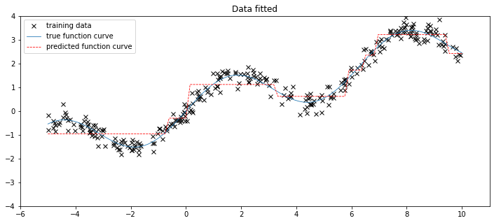

```python
# Try to predict everywhere to see the predicted function curve
y_predict = RegTree.predict(model_tree, x_all)

# Plot the data. How does it look like compared to the curves you already fitted in all previous sections?
# Similarly, try to experiment with different parameters in configuring your Decision Tree.
plt.figure(figsize=(12,5))
plt.xlim([-6., 11])
plt.ylim([-4, 4])
plt.title('Data fitted')
plt.plot(x_train,y_train,'kx',label='training data')
plt.plot(x_all, y_true, linewidth=.8, label='true function curve')
plt.plot(x_all, y_predict, '--r', linewidth=.8, label='predicted function curve')
plt.legend()
```

```python
# performance on training
performance(RegTree.predict(model_tree, x_train),y_train)
```

```
{'R2': 0.9324112557555028,
 'expvar': 0.9324112557555028,
 'MAE': 0.3225819339784243,
 'RMSE': 0.4004131817672243,
 'MAPE': 0.33567422144308706}
```

```python
# performance on the test set
performance(RegTree.predict(model_tree, x_val),y_val)
```

```
{'R2': 0.9101880220421306,
 'expvar': 0.9105155051428564,
 'MAE': 0.3557782794419797,
 'RMSE': 0.44343075205121557,
 'MAPE': 0.4014994888138325}
```

### 4.1 Decision Tree in sklearn

Cost complexity pruning provides control to the size of a tree. In Sklearn, this pruning technique is parameterized by the cost complexity parameter, ccp_alpha. Greater values of ccp_alpha increase the number of nodes pruned. In practice, you also see people tune the maximum depth of a tree instead o the cost complexity. It is simpler and for simple cases it works well, but there is no proof that we will find the best tree.

```
{'R2': 0.914821407445777, 'expvar': 0.914948582112942, 'MAE': 0.34681871240558976, 'RMSE': 0.4347137143103996, 'MAPE': 0.3671654427561017}
```

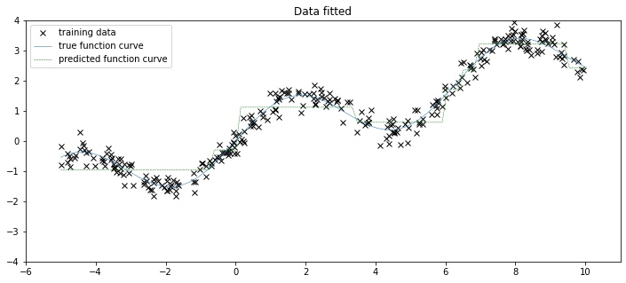

```python
# Initiate a tree model
tree_depth = 3
model_tree = DecisionTreeRegressor(max_depth=tree_depth)
# try a linear model
# model_tree = LinearRegression()

# Fit the model to your data.
# Please note that the output of this fitting is a model with several parameters that are configurable, so far you only configured "max_depth" while training/fitting.
model_tree.fit(x_train, y_train)

# Use the fitted model to predict every where for visualizing the fitted curve
y_predict = model_tree.predict(x_all)
# Plot
plt.figure(figsize=(12,5))
plt.xlim([-6., 11])
plt.ylim([-4, 4])
plt.title('Data fitted')
plt.plot(x_train,y_train,'kx',label='training data')
plt.plot(x_all, y_true, linewidth=.5, label='true function curve')
plt.plot(x_all, y_predict, '--g', linewidth=.5, label='predicted function curve')
plt.legend()
print(performance( model_tree.predict(x_val), y_val))
```

##### Cost complexity pruning

```
Number of nodes in the last tree is: 1 with ccp_alpha: 1.7143566650915671
```

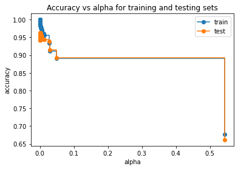

```python
clf = DecisionTreeRegressor(random_state=0)
clfs = []

path = clf.cost_complexity_pruning_path(x_train, y_train)
ccp_alphas  = path.ccp_alphas
for ccp_alpha in ccp_alphas:
    clf = DecisionTreeRegressor(random_state=0, ccp_alpha=ccp_alpha)
    clf.fit(x_train, y_train)
    clfs.append(clf)
print("Number of nodes in the last tree is: {} with ccp_alpha: {}".format(
      clfs[-1].tree_.node_count, ccp_alphas[-1]))

clfs = clfs[:-1] # remove the last element in clfs and ccp_alphas, because it is the trivial tree with only one node.
ccp_alphas = ccp_alphas[:-1]

train_scores = [clf.score(x_train, y_train) for clf in clfs]
test_scores = [clf.score(x_val, y_val) for clf in clfs]

fig, ax = plt.subplots()
ax.set_xlabel("alpha")
ax.set_ylabel("accuracy")
ax.set_title("Accuracy vs alpha for training and testing sets")
ax.plot(ccp_alphas, train_scores, marker='o', label="train",
        drawstyle="steps-post")
ax.plot(ccp_alphas, test_scores, marker='o', label="test",
        drawstyle="steps-post")
ax.legend()
plt.show()
```

```python
best_alpha=ccp_alphas[np.argmax(test_scores )]
```

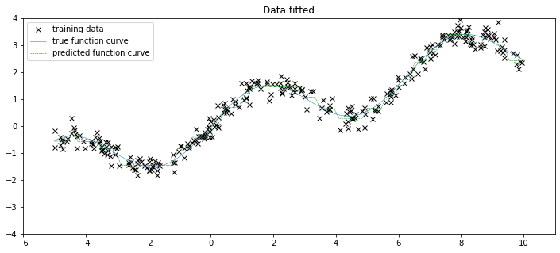

```python
# After we obtained the optimal ccp_alpha, we can use it to fit the model
model_tree = DecisionTreeRegressor(random_state=0, ccp_alpha = best_alpha)
model_tree.fit(x_train, y_train)
# Use the fitted model to predict every where for visualizing the fitted curve
y_predict = model_tree.predict(x_all)
# Plot
plt.figure(figsize=(12,5))
plt.xlim([-6., 11])
plt.ylim([-4, 4])
plt.title('Data fitted')
plt.plot(x_train,y_train,'kx',label='training data')
plt.plot(x_all, y_true, linewidth=.5, label='true function curve')
plt.plot(x_all, y_predict, '--g', linewidth=.5, label='predicted function curve')
plt.legend()
```

```python
print(performance( model_tree.predict(x_val), y_val))
```

```
{'R2': 0.9610675460878745, 'expvar': 0.9610814452762912, 'MAE': 0.24886809029665843, 'RMSE': 0.3022208569248789, 'MAPE': 0.2977059741836035}
```

#### Model interpretation

```
[Text(426.1090909090909, 464.778, 'X[0] <= 5.944\nmse = 2.532\nsamples = 300\nvalue = 0.881'),
```

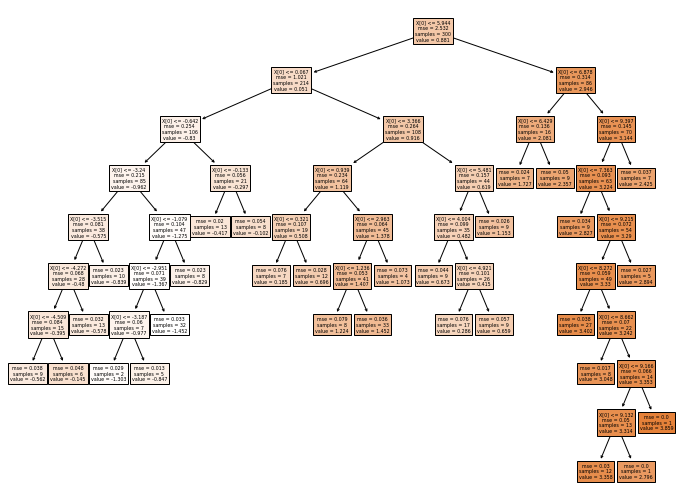

```python
# Try to interpret what is going on along the tree nodes.
# Hint: since there is only 1 dimension in the dataset, it means the dataset has always been splitted on the first dimension.
# X[0] means the first dimension of the dataset.
fig = plt.figure(figsize=(tree_depth*4,tree_depth*3))  # Adjust figure size according to the tree shape
tree.plot_tree(model_tree, filled=True)
```

### Short exercise

The above example applied the **decision tree** to the original dummy dataset with 1 **dimension**. What if you have a dataset with higher **dimensions**? Actually, you should be familiar with this situation. In the example of polynomial model fitting, we have already projected our input **X** into higher dimensions by using the polynomial transformation!

It's all about perspective. Polynomial regression is essentially a linear regression in high dimensions, where each dimension in *(x<sub>1</sub>, x<sub>2</sub>, x<sub>3</sub>,..., x<sub>n</sub>)* are also called polynomial **features** of the input *x* in the form of *(x<sup>1</sup>, x<sup>2</sup>, x<sup>3</sup>,..., x<sup>n</sup>)*. At this moment, it is also important to stress that **dimensions**, **features**, and **variables** are commonly used interchangably in many data science study cases. For instance, as we mentioned in *section 1.1*, polynomial regression is also a multi **variable** regression that each polynomial term can be treated as a input variable.

So, try to experiment with your tree configuration to inspect how the parameters of a tree impact the regression results. And how the data points are used to split the dataset at each node of your tree model. In the following section, you will see a **decision tree** model be trained with 2-dimensional input data **X**. Try to understand the following code and modify the input data dimensionality, and interpret the visualization.

```
[Text(334.8, 428.08500000000004, 'X[0] <= 5.944\nmse = 2.532\nsamples = 300\nvalue = 0.881'),
```

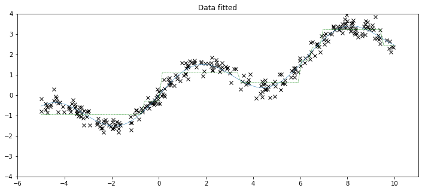

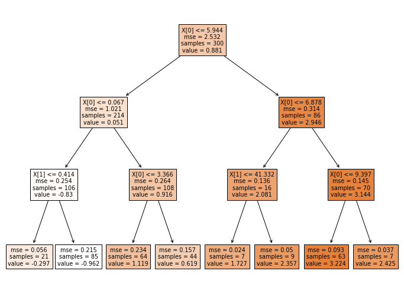

```python
# Define a fuction that project inputs into higher order polynomial inputs.
# For instance, when degree=3, x becomes to (x, x^2, x^3).
def transform(x, degree):
    # Transforms input array with polynomial features
    # x : (sample_size, n) ndarray
    # Output : (sample_size, 1 + nC1 + ... + nCd) ndarray

    if x.ndim == 1:
        x = x[:, None]
    x_t = x.transpose()
    features = []
    for degree in range(1, degree + 1):
        for items in itertools.combinations_with_replacement(x_t, degree):
            features.append(functools.reduce(lambda x, y: x * y, items))
    return np.asarray(features).transpose()

# Initiate a tree model
tree_depth = 3
model_tree = DecisionTreeRegressor(max_depth=tree_depth,random_state=0)

# First transform inputs with higher order features based upon the degree
deg = 2  # Again, similar as in section 1.1, 8 degree is used.
# Fit the model to your data.
x_poly = transform(x_train,deg)
model_tree.fit(x_poly, y_train)

# Use the fitted model to predict every where for visualizing the fitted curve
y_predict = model_tree.predict(transform(x_all,deg))

# Plot
plt.figure(figsize=(12,5))
plt.xlim([-6., 11])
plt.ylim([-4, 4])
plt.title('Data fitted')
plt.plot(x_train,y_train,'kx',label='training data')
plt.plot(x_all, y_true, linewidth=.5)
plt.plot(x_all, y_predict, '--g', linewidth=.5)

# Tree visualization
fig = plt.figure(figsize=(tree_depth*4,tree_depth*3))  # Adjust figure size according to the tree shape
tree.plot_tree(model_tree, filled=True)
```

Along the tree model, you have already seen that some data value on certain dimension is best for splitting data. It means that certain data point of a dimension or feature can be used best for capture data variance. It then indicate some data dimension or input feature are more important than the others for our regression analysis.

In **decision tree** model, it allows you to rank the feature importance for your tree-based regression.

```
Feature: 0, Score: 0.98733
Feature: 1, Score: 0.01267
```

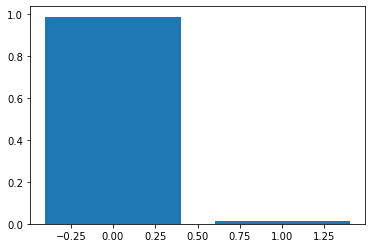

```python
# Get feature importance
importance = model_tree.feature_importances_
# summarize feature importance
for i,v in enumerate(importance):
    print('Feature: %0d, Score: %.5f' % (i,v))

# Plot feature importance
plt.bar([ind for ind in range(len(importance))], importance)
plt.show()
```

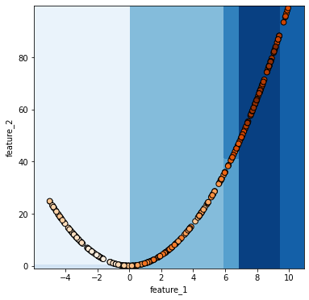

```python
# The tree-based model can also be visualized in a different way to see how data has been splitted.
# Let's plot how the features split the data

# Plot parameters
plot_colors = "ryb"
plot_step = 0.02

# Plot the decision boundary
plt.figure(figsize=(6, 6))

x_min, x_max = x_poly[:, 0].min() - 1, x_poly[:, 0].max() + 1
y_min, y_max = x_poly[:, 1].min() - 1, x_poly[:, 1].max() + 1
xx, yy = np.meshgrid(np.arange(x_min, x_max, plot_step),
                     np.arange(y_min, y_max, plot_step))
plt.tight_layout(h_pad=0.5, w_pad=0.5, pad=2.5)

Z = model_tree.predict(np.c_[xx.ravel(), yy.ravel()])
Z = Z.reshape(xx.shape)
cs = plt.contourf(xx, yy, Z, cmap=plt.cm.Blues)

plt.xlabel('feature_1')
plt.ylabel('feature_2')

plt.scatter(x_poly[:, 0], x_poly[:, 1], c=y_train.reshape(y_train.shape[0]), cmap='Oranges', edgecolor='black', s=45)
```

### Hyperparameter tunning

We introduce here the exhausive grid search, which is the most commonly used method. However, when the search space is large, the computation becomes heavy. There are many alternatives: https://scikit-learn.org/stable/modules/grid_search.html

```python
# Let's take a look at all the parameters in our estimator.
model_tree.get_params()
```

```
{'ccp_alpha': 0.0,
 'criterion': 'mse',
 'max_depth': 3,
 'max_features': None,
 'max_leaf_nodes': None,
 'min_impurity_decrease': 0.0,
 'min_impurity_split': None,
 'min_samples_leaf': 1,
 'min_samples_split': 2,
 'min_weight_fraction_leaf': 0.0,
 'random_state': 0,
 'splitter': 'best'}
```

```python
from sklearn.model_selection import GridSearchCV
param_grid = {'ccp_alpha': np.linspace(0, 0.001,50)}
base_estimator = DecisionTreeRegressor(random_state=0)
sh = GridSearchCV(base_estimator, param_grid, cv=10).fit(x_train, y_train)
sh.best_estimator_
```

```
DecisionTreeRegressor(ccp_alpha=0.0008979591836734694, random_state=0)
```

```python
param_grid = {'max_depth': np.linspace(2, 8, 7)}
base_estimator = DecisionTreeRegressor(random_state=0)
sh = GridSearchCV(base_estimator, param_grid, cv=10).fit(x_train, y_train)
sh.best_estimator_
```

```
DecisionTreeRegressor(max_depth=5.0, random_state=0)
```

Now we can use the optimised hyper-parameters:

```python
base_estimator = DecisionTreeRegressor(random_state=0, ccp_alpha=0.00088)
base_estimator.fit(x_train, y_train)
print(performance( base_estimator.predict(x_val), y_val))
```

```
{'R2': 0.9610675460878745, 'expvar': 0.9610814452762912, 'MAE': 0.24886809029665843, 'RMSE': 0.3022208569248789, 'MAPE': 0.2977059741836035}
```

```python
base_estimator = DecisionTreeRegressor(random_state=0, max_depth=5)
base_estimator.fit(x_train, y_train)
print(performance( base_estimator.predict(x_val), y_val))
```

```
{'R2': 0.964023952198793, 'expvar': 0.9640708744557233, 'MAE': 0.23970712098601543, 'RMSE': 0.2910767902615695, 'MAPE': 0.2635789427989597}
```

## Assignment:

1. From the 𝑁𝑂2 dataset (DENL17_uc.csv), select 3 (numerical) variables which you used for your linear regression assignment.
2. Use a regression tree estimator, tune the "ccp_alpha" hyperparameter. Plot the relationship between different values of "ccp_alpha" vs. prediction accuracy.
3. Fit the tree to the training data.
4. Analyse the model performance.
5. Plot the tree.
6. Which features are considered important by the regression tree algorithm? .